# Project 1: Wrangling, Exploration, Visualization

SDS322E

```r
library(tidyverse)
library(ggplot2)
library(dplyr)
library(tidyr)
library(formatR)
```

## Data Wrangling, Exploration, Visualization

### Shaojie Hou, sh49854

#### Introduction

**In this project, I’m going to explore the relationship between Living Happiness Quality and Population among different countries and regions in the world. There will be various criteria index of happiness of different countries in the first csv file ‘world-happiness-report-2021.csv’ and variables of population and countries in the second file ‘2021_population.csv’. I chose to analyze those two aspects of countries in the world because I want to confirm if the larger population in a country will lead to lower living quality or sense of happiness of its people. Those two dataframes are obtained from Kaggle and updated within the most recent year.**

```r
# read your datasets in here, e.g., with read_csv()
world_happiness = read.csv("world-happiness-report-2021.csv")
world_population = read.csv("2021_population.csv")
```

**Read csv file from home directory and assign names for those data frames**

#### Tidying: Reshaping

If your datasets are tidy already, demonstrate that you can reshape data with pivot wider/longer here (e.g., untidy and then retidy). Alternatively, it may be easier to wait until the wrangling section so you can reshape your summary statistics. Note here if you are going to do this.

```r
# your tidying code (if applicable; can also wait until
# wrangling section)
world_population %>%
    pivot_longer((3:4), names_to = "data_collected_year", values_to = "population") ->
    population_untidy

population_untidy %>%
    pivot_wider(names_from = "data_collected_year", values_from = "population") %>%
    rename(., c(population_2021 = "X2021_last_updated")) %>%
    rename(., c(population_2020 = "X2020_population")) %>%
    rename(., c(world_percentage = "world_.")) -> population_tidy
```

**Utilize pivot_wider and pivot_longer of the population data frame based on the population in different years to make the data frame tidy; rename untidy columns**

#### Joining/Merging

```r
world_happiness %>%
    left_join(population_tidy, by = c(Country.name = "country")) %>%
    na.omit() -> happiness_population
```

```r
anti_join(world_happiness, population_tidy, by = c(Country.name = "country"))
```

```
##                Country.name         Regional.indicator Ladder.score
## 1  Taiwan Province of China                  East Asia        6.584
## 2                    Kosovo Central and Eastern Europe        6.372
## 3    Bosnia and Herzegovina Central and Eastern Europe        5.813
## 4              North Cyprus             Western Europe        5.536
## 5 Hong Kong S.A.R. of China                  East Asia        5.477
##   Standard.error.of.ladder.score upperwhisker lowerwhisker
## 1                          0.038        6.659        6.510
## 2                          0.059        6.487        6.257
## 3                          0.050        5.911        5.715
## 4                          0.051        5.636        5.435
## 5                          0.049        5.573        5.380
##   Logged.GDP.per.capita Social.support Healthy.life.expectancy
## 1                10.871          0.898                  69.600
## 2                 9.318          0.821                  63.813
```

[output cut: 34 more lines]

```r
anti_join(population_tidy, world_happiness, by = c(country = "Country.name"))
```

```
## # A tibble: 87 × 9
##    iso_code country    area     density_sq_km growth_rate world_percentage  rank
##    <chr>    <chr>      <chr>    <chr>         <chr>       <chr>            <int>
##  1 COD      Dr Congo   2,344,8… 39/sq_km      3.14%       1.17%               16
##  2 SDN      Sudan      1,886,0… 24/sq_km      2.42%       0.57%               33
##  3 AGO      Angola     1,246,7… 27/sq_km      3.25%       0.43%               43
##  4 PRK      North Kor… 120,538… 215/sq_km     0.42%       0.33%               54
##  5 TWN      Taiwan     36,193 … 659/sq_km     0.16%       0.30%               57
##  6 SYR      Syria      185,180… 99/sq_km      4.43%       0.23%               66
##  7 SOM      Somalia    637,657… 26/sq_km      2.93%       0.21%               73
##  8 SSD      South Sud… 619,745… 18/sq_km      1.68%       0.14%               83
##  9 CUB      Cuba       109,884… 103/sq_km     -0.08%      0.14%               84
## 10 PNG      Papua New… 462,840… 20/sq_km      1.92%       0.12%               97
## # … with 77 more rows, and 2 more variables: population_2021 <chr>,
## #   population_2020 <chr>
```

**Based on the observation of anti_join, we can figure out that there are 87 countries in world population dataframe but not in world_happiness dataframe which are unique for world population dataframe.**

#### Wrangling

##### (1)

```r
# Since the growth rate, world percentage, population in
# 2021, and population in 2020 are characters with comma or
# percentage, we cannot directly convert those columns with
# 'as.numeric()'. I used stringr and regex to remove those
# signs and mutate them with original columns to change
# their data type to 'dbl' for further analysis.

population_2021 = happiness_population$population_2021
tidy_population_2021 = str_remove_all(population_2021, "\\,")
population_2020 = happiness_population$population_2020
tidy_population_2020 = str_remove_all(population_2020, "\\,")
world_percentage = happiness_population$world_percentage
tidy_world_percentage = str_remove_all(world_percentage, "\\%")
growth_rate = happiness_population$growth_rate
tidy_growth_rate = str_remove_all(growth_rate, "\\%")

happiness_population %>%
    mutate(population_2021 = tidy_population_2021) %>%
    mutate(population_2021 = as.numeric(population_2021)) %>%
    mutate(population_2020 = tidy_population_2020) %>%
    mutate(population_2020 = as.numeric(population_2020)) %>%
    mutate(world_percentage = tidy_world_percentage) %>%
    mutate(world_percentage = as.numeric(world_percentage)) %>%
    mutate(growth_rate = tidy_growth_rate) %>%
    mutate(growth_rate = as.numeric(growth_rate)) %>%
    rename(., c(growth_rate_percentage = "growth_rate")) %>%
    rename(., c(population_rank = "rank")) -> numeric_population


numeric_population %>%
    select(c("Country.name", "Regional.indicator", "Ladder.score")) %>%
    filter(Ladder.score >= 7) %>%
    select(1:3) %>%
    group_by(Regional.indicator) %>%
    summarize(n())
```

```
## # A tibble: 4 × 2
##   Regional.indicator           `n()`
##   <chr>                        <int>
## 1 Latin America and Caribbean      1
## 2 Middle East and North Africa     1
## 3 North America and ANZ            3
## 4 Western Europe                  12
```

**Among all countries having ladder score over 7, we can find out that Western Europe has largest amount of them.**

##### Summarize(1)

```r
numeric_population %>%
    group_by(Country.name) %>%
    summarize(population_increasing = population_2021 - population_2020,
        n()) %>%
    arrange(desc(population_increasing))
```

```
## # A tibble: 141 × 3
##    Country.name  population_increasing `n()`
##    <chr>                         <dbl> <int>
##  1 India                      17896582     1
##  2 Nigeria                     7027407     1
##  3 China                       6512082     1
##  4 Pakistan                    5742951     1
##  5 Ethiopia                    3887185     1
##  6 Indonesia                   3790660     1
##  7 Egypt                       2567658     1
##  8 United States               2562405     1
##  9 Tanzania                    2356004     1
## 10 Bangladesh                  2150765     1
## # … with 131 more rows
```

**Based on the data we summarize above, from 2020 to 2021, we can see that the population increases the most in India and the least in Japan which is even negative.**

##### Summarize(2)

```r
numeric_population %>%
    group_by(Regional.indicator) %>%
    summarize(mean(Explained.by..Perceptions.of.corruption),
        n()) %>%
    arrange(`mean(Explained.by..Perceptions.of.corruption)`)
```

```
## # A tibble: 10 × 3
##    Regional.indicator                 `mean(Explained.by..Perceptions.of.… `n()`
##    <chr>                                                             <dbl> <int>
##  1 Central and Eastern Europe                                       0.0629    15
##  2 South Asia                                                       0.0906     7
##  3 Latin America and Caribbean                                      0.0936    20
##  4 Sub-Saharan Africa                                               0.109     34
##  5 Middle East and North Africa                                     0.115     16
##  6 East Asia                                                        0.124      4
##  7 Commonwealth of Independent States                               0.137     12
##  8 Southeast Asia                                                   0.147      9
##  9 Western Europe                                                   0.269     20
## 10 North America and ANZ                                            0.313      4
```

**Based on the data we summarize above, we can see that the situation of corruption is the most serious in Central and East Europe and least serious in North America and ANZ**

##### Summarize(3)

```r
numeric_population %>%
    group_by(Regional.indicator) %>%
    summarize(max(population_2021), n()) %>%
    arrange(desc(`max(population_2021)`))
```

```
## # A tibble: 10 × 3
##    Regional.indicator                 `max(population_2021)` `n()`
##    <chr>                                               <dbl> <int>
##  1 East Asia                                      1445835858     4
##  2 South Asia                                     1397900967     7
##  3 North America and ANZ                           333565056     4
##  4 Southeast Asia                                  277314275     9
##  5 Latin America and Caribbean                     214470663    20
##  6 Sub-Saharan Africa                              213166996    34
##  7 Commonwealth of Independent States              145905164    12
##  8 Middle East and North Africa                    104902062    16
##  9 Western Europe                                   83943233    20
## 10 Central and Eastern Europe                       37778504    15
```

**Based on the data we summarize above, we can see that the maximum of population is in East Asia and the minimum of population is in Central and Eastern Europe.**

##### Summarize(4)

```r
numeric_population %>%
    group_by(Regional.indicator) %>%
    summarize(mean(Explained.by..Log.GDP.per.capita), n()) %>%
    arrange(desc(`mean(Explained.by..Log.GDP.per.capita)`))
```

```
## # A tibble: 10 × 3
##    Regional.indicator                 `mean(Explained.by..Log.GDP.per.cap… `n()`
##    <chr>                                                             <dbl> <int>
##  1 Western Europe                                                    1.47     20
##  2 North America and ANZ                                             1.46      4
##  3 Central and Eastern Europe                                        1.24     15
##  4 East Asia                                                         1.20      4
##  5 Middle East and North Africa                                      1.08     16
##  6 Southeast Asia                                                    0.974     9
##  7 Commonwealth of Independent States                                0.966    12
##  8 Latin America and Caribbean                                       0.955    20
##  9 South Asia                                                        0.715     7
## 10 Sub-Saharan Africa                                                0.492    34
```

**Based on the data we summarize above, we can see that Europe has the highest GDP per capita and Sub-Saharan Africa has the lowest GDP per capita.**

##### Summarize(5)

```r
numeric_population %>%
    group_by(Regional.indicator) %>%
    summarize(mean(Explained.by..Freedom.to.make.life.choices),
        n()) %>%
    arrange(desc(`mean(Explained.by..Freedom.to.make.life.choices)`))
```

```
## # A tibble: 10 × 3
##    Regional.indicator                 `mean(Explained.by..Freedom.to.make… `n()`
##    <chr>                                                             <dbl> <int>
##  1 Southeast Asia                                                    0.641     9
##  2 North America and ANZ                                             0.629     4
##  3 Western Europe                                                    0.584    20
##  4 Latin America and Caribbean                                       0.548    20
##  5 Commonwealth of Independent States                                0.530    12
##  6 Central and Eastern Europe                                        0.507    15
##  7 East Asia                                                         0.473     4
##  8 South Asia                                                        0.466     7
##  9 Sub-Saharan Africa                                                0.419    34
## 10 Middle East and North Africa                                      0.412    16
```

##### Summarize(6)

```r
numeric_population %>%
    group_by(Regional.indicator) %>%
    summarize(sum(population_2021), n()) %>%
    arrange(desc(`sum(population_2021)`))
```

```
## # A tibble: 10 × 3
##    Regional.indicator                 `sum(population_2021)` `n()`
##    <chr>                                               <dbl> <int>
##  1 South Asia                                     1883426471     7
##  2 East Asia                                      1626411847     4
##  3 Sub-Saharan Africa                              954797155    34
##  4 Southeast Asia                                  675499636     9
##  5 Latin America and Caribbean                     641286396    20
##  6 Middle East and North Africa                    526657840    16
##  7 Western Europe                                  426632305    20
##  8 North America and ANZ                           402502481     4
##  9 Commonwealth of Independent States              295731029    12
## 10 Central and Eastern Europe                      115846204    15
```

**Based on the data we summarize above, based on the unit of regional indicator, the largest total population appears in South Asia and the smallest total population appears in Central and Eastern Europe.**

##### Summarize(7)

```r
regional_poplulation_diff = function(x) {
    max(x) - min(x)
}

numeric_population %>%
    select("Country.name", "Regional.indicator", "Explained.by..Log.GDP.per.capita") %>%
    group_by(Regional.indicator) %>%
    summarise(regional_poplulation_diff(Explained.by..Log.GDP.per.capita),
        n()) %>%
    arrange(desc(`regional_poplulation_diff(Explained.by..Log.GDP.per.capita)`))
```

```
## # A tibble: 10 × 3
##    Regional.indicator                 `regional_poplulation_diff(Explaine… `n()`
##    <chr>                                                             <dbl> <int>
##  1 Middle East and North Africa                                      1.23     16
##  2 Sub-Saharan Africa                                                1.18     34
##  3 Southeast Asia                                                    1.09      9
##  4 Latin America and Caribbean                                       1.00     20
##  5 South Asia                                                        0.745     7
##  6 Commonwealth of Independent States                                0.733    12
##  7 Western Europe                                                    0.478    20
##  8 East Asia                                                         0.437     4
##  9 Central and Eastern Europe                                        0.362    15
## 10 North America and ANZ                                             0.133     4
```

**Based on the data we summarize above, we can see that the gap between rich and poor is the greatest in Middle East and North Africa and least in North America and ANZ**

##### Summarize(8)

```r
numeric_population %>%
    select("Country.name", "Regional.indicator", "Explained.by..Log.GDP.per.capita") %>%
    group_by(Regional.indicator) %>%
    summarise(sd(Explained.by..Log.GDP.per.capita), n()) %>%
    arrange(desc(`sd(Explained.by..Log.GDP.per.capita)`))
```

```
## # A tibble: 10 × 3
##    Regional.indicator                 `sd(Explained.by..Log.GDP.per.capit… `n()`
##    <chr>                                                             <dbl> <int>
##  1 Southeast Asia                                                   0.339      9
##  2 Middle East and North Africa                                     0.316     16
##  3 Sub-Saharan Africa                                               0.282     34
##  4 South Asia                                                       0.260      7
##  5 Latin America and Caribbean                                      0.227     20
##  6 East Asia                                                        0.224      4
##  7 Commonwealth of Independent States                               0.218     12
##  8 Central and Eastern Europe                                       0.114     15
##  9 Western Europe                                                   0.107     20
## 10 North America and ANZ                                            0.0552     4
```

##### Summarize(9)

```r
numeric_population %>%
    group_by(Regional.indicator) %>%
    summarize(sum(world_percentage), n()) %>%
    arrange(desc(`sum(world_percentage)`))
```

```
## # A tibble: 10 × 3
##    Regional.indicator                 `sum(world_percentage)` `n()`
##    <chr>                                                <dbl> <int>
##  1 South Asia                                           23.8      7
##  2 East Asia                                            20.6      4
##  3 Sub-Saharan Africa                                   12.0     34
##  4 Southeast Asia                                        8.56     9
##  5 Latin America and Caribbean                           8.12    20
##  6 Middle East and North Africa                          6.65    16
##  7 Western Europe                                        5.42    20
##  8 North America and ANZ                                 5.1      4
##  9 Commonwealth of Independent States                    3.74    12
## 10 Central and Eastern Europe                            1.48    15
```

**Based on the data we summarize above, we can see that South Asia takes the largest percentage of population in the world; by contrast, Ventral and Eastern Europe takes the smallest percentage.**

##### Summarize(10)

```r
numeric_population %>%
    filter(population_rank > 50) %>%
    group_by(Regional.indicator) %>%
    summarise(n()) %>%
    arrange(desc(`n()`))
```

```
## # A tibble: 10 × 2
##    Regional.indicator                 `n()`
##    <chr>                              <int>
##  1 Sub-Saharan Africa                    26
##  2 Western Europe                        15
##  3 Central and Eastern Europe            14
##  4 Latin America and Caribbean           14
##  5 Commonwealth of Independent States     9
##  6 Middle East and North Africa           8
##  7 Southeast Asia                         3
##  8 North America and ANZ                  2
##  9 South Asia                             2
## 10 East Asia                              1
```

#### Visualizing

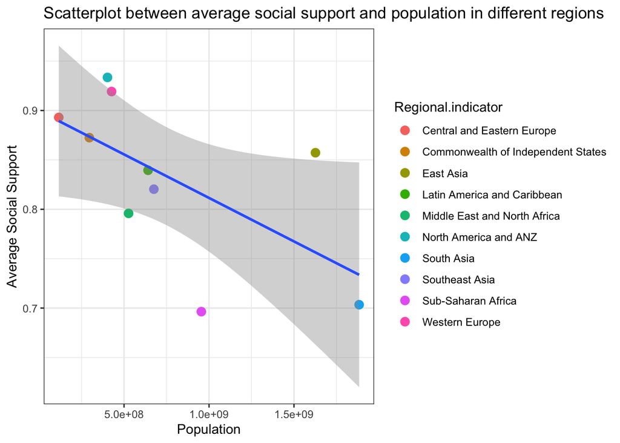

```r
numeric_population %>%
    group_by(Regional.indicator) %>%
    mutate(average_socialsupport = mean(Social.support)) %>%
    summarize(sum(population_2021), average_socialsupport) %>%
    distinct() %>%
    ggplot(., aes(x = `sum(population_2021)`, y = average_socialsupport)) +
    geom_point(size = 3, aes(color = Regional.indicator)) + geom_smooth(method = "lm") +
    theme_bw() + ggtitle("Scatterplot between average social support and population in different regions") +
    xlab("Population") + ylab("Average Social Support")
```

**Based on the graph above, we can find out that, in general, the higher average social support, the smaller population the region has.**

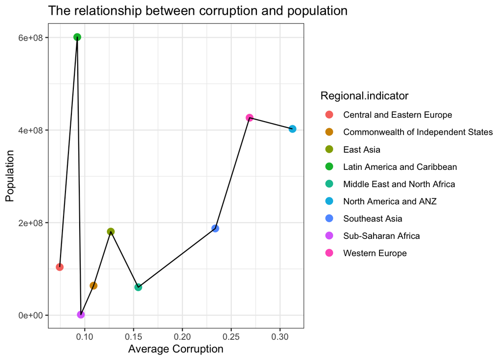

```r
numeric_population %>%
    filter(Ladder.score > mean(Ladder.score)) %>%
    group_by(Regional.indicator) %>%
    summarize(mean(Explained.by..Perceptions.of.corruption),
        sum(population_2021)) %>%
    ggplot(., aes(x = `mean(Explained.by..Perceptions.of.corruption)`,
        y = `sum(population_2021)`)) + geom_point(size = 3, aes(color = Regional.indicator)) +
    geom_line() + theme_bw() + ggtitle("The relationship between corruption and population") +
    xlab("Average Corruption") + ylab("Population")
```

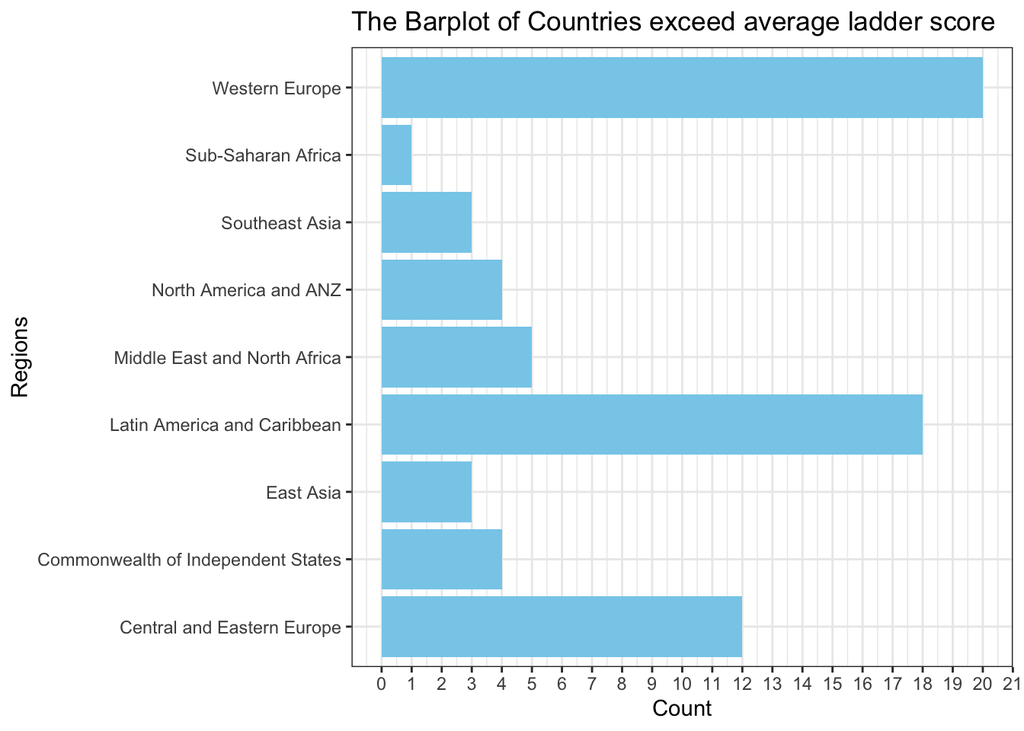

```r
numeric_population %>%
    select(c("Country.name", "Regional.indicator", "Ladder.score")) %>%
    filter(Ladder.score >= mean(Ladder.score)) %>%
    select(1:3) %>%
    group_by(Regional.indicator) %>%
    summarize(n()) %>%
    ggplot(., aes(x = `n()`, y = Regional.indicator)) + geom_bar(stat = "summary",
    fun = mean, fill = "skyblue") + geom_errorbar(stat = "summary",
    width = 0.5) + theme_bw() + ggtitle("The Barplot of Countries exceed average ladder score") +
    xlab("Count") + ylab("Regions") + scale_x_continuous(breaks = seq(0,
    25, 1))
```

**For all the countries exceeds the average ladder score, Western Europe has the largest amount and Sub-Saharan Africa has the least amount.**